# STAT 311 – Lab 3

Group 17

Owen Cheung, Steven Tran

Wednesday, August 3, 2022 @ 11:59pm

## Question 1: Exercise and General Health

### Part a)

```r
contingency <- table(cdc$exerany, cdc$genhlth)
print.table(contingency)
```

```
##
##     poor fair good very good excellent
##   n  384  857 1731      1352       762
##   y  293 1162 3944      5620      3895
```

```r
contingency_margins <- addmargins(contingency)
print.table(contingency_margins)
```

```
##
##        poor  fair  good very good excellent   Sum
##   n     384   857  1731      1352       762  5086
##   y     293  1162  3944      5620      3895 14914
##   Sum   677  2019  5675      6972      4657 20000
```

### Part b)

```r
contingency <- table(cdc$exerany, cdc$genhlth)
print.table(contingency)
```

```
##
##     poor fair good very good excellent
##   n  384  857 1731      1352       762
##   y  293 1162 3944      5620      3895
```

```r
contingency_margins <- addmargins(contingency)
print.table(contingency_margins)
```

```
##
##        poor  fair  good very good excellent   Sum
##   n     384   857  1731      1352       762  5086
##   y     293  1162  3944      5620      3895 14914
##   Sum   677  2019  5675      6972      4657 20000
```

```r
contingency_prop <- prop.table(contingency)
print(contingency_prop)
```

```
##
##        poor    fair    good very good excellent
##   n 0.01920 0.04285 0.08655   0.06760   0.03810
##   y 0.01465 0.05810 0.19720   0.28100   0.19475
```

The proportion of those who have exercised in the past month which is the yes to the variable exerany is 14914/20000, which is 0.7457. The proportion of the sample reporting excellent health is 4657/20000 or 0.23285. These numbers are supported by both `contingency_prop` and `contingency_margins`.

### Part c)

```r
contingency_prop <- prop.table(contingency)
print(contingency_prop)
```

```
##
##        poor    fair    good very good excellent
##   n 0.01920 0.04285 0.08655   0.06760   0.03810
##   y 0.01465 0.05810 0.19720   0.28100   0.19475
```

### Part d)

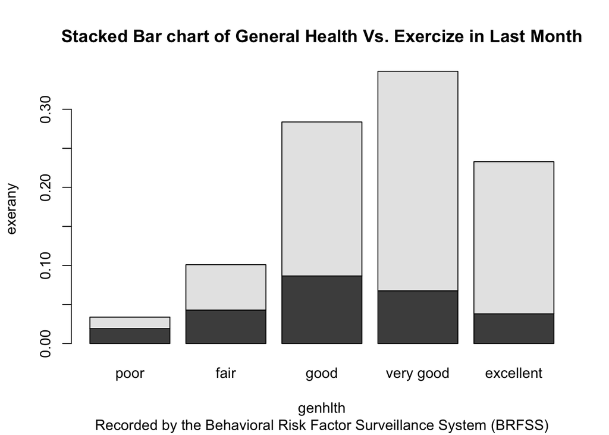

```r
bar_chart <- barplot(contingency_prop,
                     main = "Stacked Bar chart of General Health Vs. Exercize in Last Month",
                     sub = "Recorded by the Behavioral Risk Factor Surveillance System (BRFSS)",
                     xlab = "genhlth",
                     ylab = "exerany",
                     axes = TRUE)
```

It seems as though most people would rate their health as very good, though those who exercize more make up more of the excellent, very good, good, and fair categories. The lighter grey represents those who have exercized within the past month and the darker grey represents those who didn’t. I also see some response bias here where those who responded tended to have better health, which may perhaps mean that they had strong feelings for this topic. There doesn’t seem to be a large ‘no exercize group’.

### Part e)

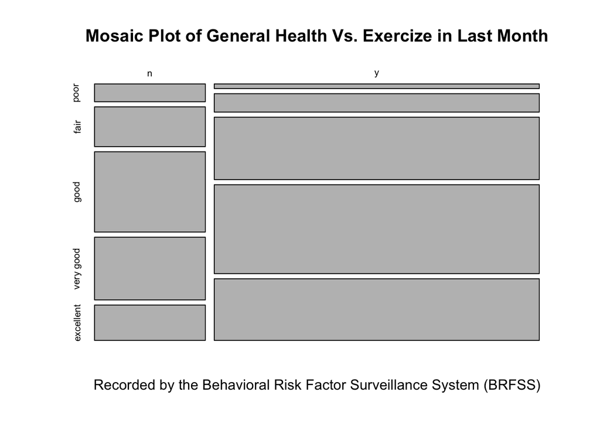

```r
mosaic_plot <- mosaicplot(contingency_prop,
                          main = "Mosaic Plot of General Health Vs. Exercize in Last Month",
                     sub = "Recorded by the Behavioral Risk Factor Surveillance System (BRFSS)")
```

Based on the plots, both the stacked bar chart and the mosaic plot, it seems as though those who exercized in the past month rated their general health higher than the population that didn’t. It also seems like the people who didn’t exercize may have been subjected to wording bias, maybe they felt bad for having not exercized. There is also response and non-response bias where there is a lot more responses from the people who exercized, and those who didn’t exercize perhaps wouldn’t have worse health than shown here on the graph.

### Part f)

No, it doesn’t seem like the two variables exerany and genhealth are independent. The people who said they exercized in the past month tend to indicate a higher level of general health. However, all we can say is that there is a correlation, not a causation, because there many be many other confounding variables that may impact a person’s general health.

## Question 2: Linear Regression

```r
# reading in (loading) the data set
mlb <- read.csv("https://anna-neufeld.github.io/Stat311/oiLabs/Week10/mlb11.csv")
```

### Exercise 1:

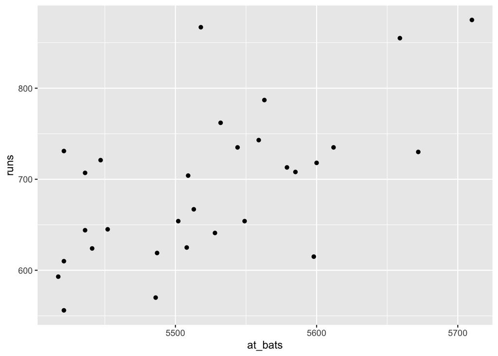

```r
plot1 <- ggplot(mlb, aes(x=at_bats, y=runs)) +
  geom_point()
print(plot1)
```

Yes this relationship looks somewhat linear because in general as x increases, y increases as well.

### Exercise 2:

I think that there seems to be a linear positive relationship between “runs” and “at bats” that is moderately strong. There may be outliers such as some of the points past 800 runs.

### Exercise 3:

**Recall:** The correlation coefficient $r$, is calculated using the below formula.

$$r = \dfrac{1}{n} \sum_{i=1}^{n} z_x z_y
= \dfrac{1}{n} \sum_{i=1}^{n} \left( \dfrac{x_i - \bar{x}}{s_x} \right)
\left( \dfrac{y_i - \bar{y}}{s_y} \right)$$
This value takes a very long time to compute by hand, especially when we have a lot of observations (i.e., a very large value for $n$. It is more efficient to compute this value using a programming language like R.

```r
test <- cor(mlb$runs, mlb$at_bats)
print(test)
```

```
## [1] 0.610627
```

r = 0.610627

### Exercise 4:

coefficients: -2370.547, 0.556 sum of squares: 126186.4

$$y = 0.556x - 2370.547$$

### Exercise 5:

644 runs

### Exercise 6:

```r
residual <- 556 - 643.529
print(residual)
```

```
## [1] -87.529
```

Since the residual was negative the answer to exercise 5 was an overestimate.

### Exercise 7:

```r
ex7 <- lm(runs ~ homeruns, data = mlb)
summary(ex7)
```

```
##
## Call:
## lm(formula = runs ~ homeruns, data = mlb)
##
## Residuals:
##     Min      1Q  Median      3Q     Max
## -91.615 -33.410   3.231  24.292 104.631
##
## Coefficients:
##             Estimate Std. Error t value Pr(>|t|)
## (Intercept) 415.2389    41.6779   9.963 1.04e-10 ***
## homeruns      1.8345     0.2677   6.854 1.90e-07 ***
## ---
## Signif. codes:  0 '***' 0.001 '**' 0.01 '*' 0.05 '.' 0.1 ' ' 1
##
## Residual standard error: 51.29 on 28 degrees of freedom
## Multiple R-squared:  0.6266, Adjusted R-squared:  0.6132
## F-statistic: 46.98 on 1 and 28 DF,  p-value: 1.9e-07
```

$$y = 1.8345x + 415.2389$$

### Exercise 8:

From adjusted r-squared we can say that 61.32% of variability in runs was able to be explained.

### Exercise 9:

```r
ex8_1 <- lm(runs ~ stolen_bases, data = mlb)
summary(ex8_1)
```

```
##
## Call:
## lm(formula = runs ~ stolen_bases, data = mlb)
##
## Residuals:
##     Min      1Q  Median      3Q     Max
## -139.94  -62.87   10.01   38.54  182.49
##
## Coefficients:
##              Estimate Std. Error t value Pr(>|t|)
## (Intercept)  677.3074    58.9751  11.485 4.17e-12 ***
## stolen_bases   0.1491     0.5211   0.286    0.777
## ---
## Signif. codes:  0 '***' 0.001 '**' 0.01 '*' 0.05 '.' 0.1 ' ' 1
##
## Residual standard error: 83.82 on 28 degrees of freedom
## Multiple R-squared:  0.002914,   Adjusted R-squared:  -0.0327
## F-statistic: 0.08183 on 1 and 28 DF,  p-value: 0.7769
```

```r
ex8_2 <- lm(runs ~ new_obs, data = mlb)
summary(ex8_2)
```

```
##
## Call:
## lm(formula = runs ~ new_obs, data = mlb)
##
## Residuals:
##     Min      1Q  Median      3Q     Max
## -43.456 -13.690   1.165  13.935  41.156
##
## Coefficients:
##             Estimate Std. Error t value Pr(>|t|)
## (Intercept)  -686.61      68.93  -9.962 1.05e-10 ***
## new_obs      1919.36      95.70  20.057  < 2e-16 ***
## ---
## Signif. codes:  0 '***' 0.001 '**' 0.01 '*' 0.05 '.' 0.1 ' ' 1
##
## Residual standard error: 21.41 on 28 degrees of freedom
## Multiple R-squared:  0.9349, Adjusted R-squared:  0.9326
## F-statistic: 402.3 on 1 and 28 DF,  p-value: < 2.2e-16
```

```r
ex8_3 <- lm(runs ~ new_slug, data = mlb)
summary(ex8_3)
```

```
##
## Call:
## lm(formula = runs ~ new_slug, data = mlb)
##
## Residuals:
##    Min     1Q Median     3Q    Max
## -45.41 -18.66  -0.91  16.29  52.29
##
## Coefficients:
##             Estimate Std. Error t value Pr(>|t|)
## (Intercept)  -375.80      68.71   -5.47 7.70e-06 ***
## new_slug     2681.33     171.83   15.61 2.42e-15 ***
## ---
## Signif. codes:  0 '***' 0.001 '**' 0.01 '*' 0.05 '.' 0.1 ' ' 1
##
## Residual standard error: 26.96 on 28 degrees of freedom
## Multiple R-squared:  0.8969, Adjusted R-squared:  0.8932
## F-statistic: 243.5 on 1 and 28 DF,  p-value: 2.42e-15
```

```r
ex8_2 <- lm(runs ~ new_obs, data = mlb)
summary(ex8_2)
```

```
##
## Call:
## lm(formula = runs ~ new_obs, data = mlb)
##
## Residuals:
##     Min      1Q  Median      3Q     Max
## -43.456 -13.690   1.165  13.935  41.156
##
## Coefficients:
##             Estimate Std. Error t value Pr(>|t|)
## (Intercept)  -686.61      68.93  -9.962 1.05e-10 ***
## new_obs      1919.36      95.70  20.057  < 2e-16 ***
## ---
## Signif. codes:  0 '***' 0.001 '**' 0.01 '*' 0.05 '.' 0.1 ' ' 1
##
## Residual standard error: 21.41 on 28 degrees of freedom
## Multiple R-squared:  0.9349, Adjusted R-squared:  0.9326
## F-statistic: 402.3 on 1 and 28 DF,  p-value: < 2.2e-16
```

```r
ex8_3 <- lm(runs ~ new_slug, data = mlb)
summary(ex8_3)
```

```
##
## Call:
## lm(formula = runs ~ new_slug, data = mlb)
##
## Residuals:
##    Min     1Q Median     3Q    Max
## -45.41 -18.66  -0.91  16.29  52.29
##
## Coefficients:
##             Estimate Std. Error t value Pr(>|t|)
## (Intercept)  -375.80      68.71   -5.47 7.70e-06 ***
## new_slug     2681.33     171.83   15.61 2.42e-15 ***
## ---
## Signif. codes:  0 '***' 0.001 '**' 0.01 '*' 0.05 '.' 0.1 ' ' 1
##
## Residual standard error: 26.96 on 28 degrees of freedom
## Multiple R-squared:  0.8969, Adjusted R-squared:  0.8932
## F-statistic: 243.5 on 1 and 28 DF,  p-value: 2.42e-15
```

```r
ex8_4 <- lm(runs ~ homeruns, data = mlb)
summary(ex8_4)
```

```
##
## Call:
## lm(formula = runs ~ homeruns, data = mlb)
##
## Residuals:
##     Min      1Q  Median      3Q     Max
## -91.615 -33.410   3.231  24.292 104.631
##
## Coefficients:
##             Estimate Std. Error t value Pr(>|t|)
## (Intercept) 415.2389    41.6779   9.963 1.04e-10 ***
## homeruns      1.8345     0.2677   6.854 1.90e-07 ***
## ---
## Signif. codes:  0 '***' 0.001 '**' 0.01 '*' 0.05 '.' 0.1 ' ' 1
##
## Residual standard error: 51.29 on 28 degrees of freedom
## Multiple R-squared:  0.6266, Adjusted R-squared:  0.6132
## F-statistic: 46.98 on 1 and 28 DF,  p-value: 1.9e-07
```

new_obs seems best to predict runs as the adjusted r-squared value of 93.26% is the highest out of all four cases which means more of the variability was able to be explained.

### Exercise 10

```r
ex10 <- lm(runs ~ new_obs, data = mlb)
summary(ex10)
```

```
##
## Call:
## lm(formula = runs ~ new_obs, data = mlb)
##
## Residuals:
##     Min      1Q  Median      3Q     Max
## -43.456 -13.690   1.165  13.935  41.156
##
## Coefficients:
##             Estimate Std. Error t value Pr(>|t|)
## (Intercept)  -686.61      68.93  -9.962 1.05e-10 ***
## new_obs      1919.36      95.70  20.057  < 2e-16 ***
## ---
## Signif. codes:  0 '***' 0.001 '**' 0.01 '*' 0.05 '.' 0.1 ' ' 1
##
## Residual standard error: 21.41 on 28 degrees of freedom
## Multiple R-squared:  0.9349, Adjusted R-squared:  0.9326
## F-statistic: 402.3 on 1 and 28 DF,  p-value: < 2.2e-16
```

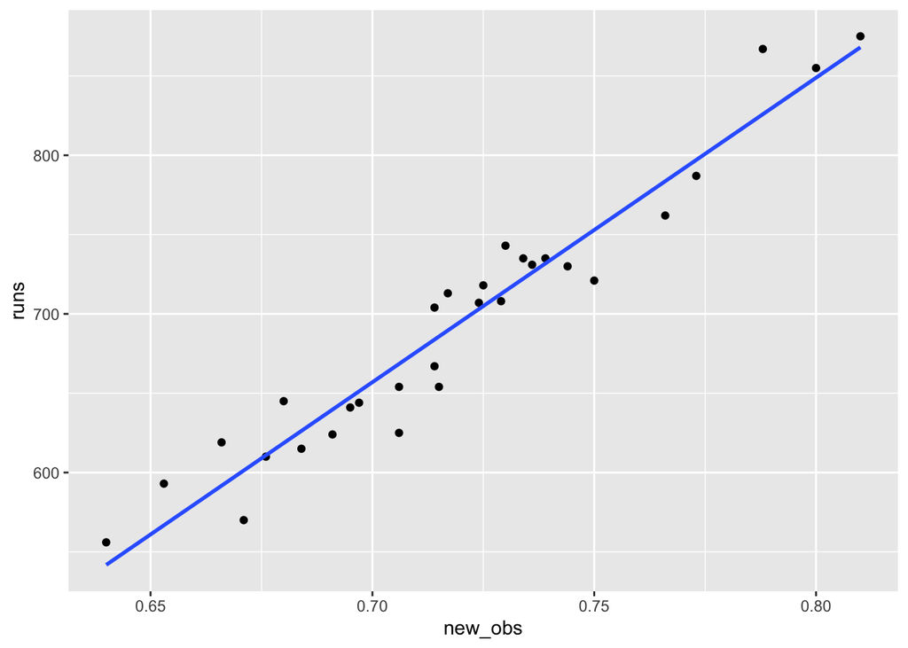

```r
# visual summaries
ex10_graph <- ggplot(mlb, aes(x=new_obs, y=runs)) + geom_point() + stat_smooth(method="lm", se=FALSE)
print(ex10_graph)
```

This model seems to show a positive linear relationship between new_obs and runs that is fairly strong. There do not seem to be any outliers.

### Exercise 11

```r
ex11_1 <- lm(runs ~ wins, data = mlb)
summary(ex11_1)
```

```
##
## Call:
## lm(formula = runs ~ wins, data = mlb)
##
## Residuals:
##      Min       1Q   Median       3Q      Max
## -145.450  -47.506   -7.482   47.346  142.186
##
## Coefficients:
##             Estimate Std. Error t value Pr(>|t|)
## (Intercept)  342.121     89.223   3.834 0.000654 ***
## wins           4.341      1.092   3.977 0.000447 ***
## ---
## Signif. codes:  0 '***' 0.001 '**' 0.01 '*' 0.05 '.' 0.1 ' ' 1
##
## Residual standard error: 67.1 on 28 degrees of freedom
## Multiple R-squared:  0.361,  Adjusted R-squared:  0.3381
## F-statistic: 15.82 on 1 and 28 DF,  p-value: 0.0004469
```

```r
ex11_2 <- lm(runs ~ strikeouts, data = mlb)
summary(ex11_2)
```

```
##
## Call:
## lm(formula = runs ~ strikeouts, data = mlb)
##
## Residuals:
##     Min      1Q  Median      3Q     Max
## -132.27  -46.95  -11.92   55.14  169.76
##
## Coefficients:
##              Estimate Std. Error t value Pr(>|t|)
## (Intercept) 1054.7342   151.7890   6.949 1.49e-07 ***
## strikeouts    -0.3141     0.1315  -2.389   0.0239 *
## ---
## Signif. codes:  0 '***' 0.001 '**' 0.01 '*' 0.05 '.' 0.1 ' ' 1
##
## Residual standard error: 76.5 on 28 degrees of freedom
## Multiple R-squared:  0.1694, Adjusted R-squared:  0.1397
## F-statistic: 5.709 on 1 and 28 DF,  p-value: 0.02386
```

```r
ex11_3 <- lm(runs ~ bat_avg, data = mlb)
summary(ex11_3)
```

```
##
## Call:
## lm(formula = runs ~ bat_avg, data = mlb)
##
## Residuals:
##     Min      1Q  Median      3Q     Max
## -94.676 -26.303  -5.496  28.482 131.113
##
## Coefficients:
##             Estimate Std. Error t value Pr(>|t|)
## (Intercept)   -642.8      183.1  -3.511  0.00153 **
## bat_avg       5242.2      717.3   7.308 5.88e-08 ***
## ---
## Signif. codes:  0 '***' 0.001 '**' 0.01 '*' 0.05 '.' 0.1 ' ' 1
##
## Residual standard error: 49.23 on 28 degrees of freedom
## Multiple R-squared:  0.6561, Adjusted R-squared:  0.6438
## F-statistic: 53.41 on 1 and 28 DF,  p-value: 5.877e-08
```

```r
ex11_2 <- lm(runs ~ strikeouts, data = mlb)
summary(ex11_2)
```

```
##
## Call:
## lm(formula = runs ~ strikeouts, data = mlb)
##
## Residuals:
##     Min      1Q  Median      3Q     Max
## -132.27  -46.95  -11.92   55.14  169.76
##
## Coefficients:
##              Estimate Std. Error t value Pr(>|t|)
## (Intercept) 1054.7342   151.7890   6.949 1.49e-07 ***
## strikeouts    -0.3141     0.1315  -2.389   0.0239 *
## ---
## Signif. codes:  0 '***' 0.001 '**' 0.01 '*' 0.05 '.' 0.1 ' ' 1
##
## Residual standard error: 76.5 on 28 degrees of freedom
## Multiple R-squared:  0.1694, Adjusted R-squared:  0.1397
## F-statistic: 5.709 on 1 and 28 DF,  p-value: 0.02386
```

```r
ex11_3 <- lm(runs ~ bat_avg, data = mlb)
summary(ex11_3)
```

```
##
## Call:
## lm(formula = runs ~ bat_avg, data = mlb)
##
## Residuals:
##     Min      1Q  Median      3Q     Max
## -94.676 -26.303  -5.496  28.482 131.113
##
## Coefficients:
##             Estimate Std. Error t value Pr(>|t|)
## (Intercept)   -642.8      183.1  -3.511  0.00153 **
## bat_avg       5242.2      717.3   7.308 5.88e-08 ***
## ---
## Signif. codes:  0 '***' 0.001 '**' 0.01 '*' 0.05 '.' 0.1 ' ' 1
##
## Residual standard error: 49.23 on 28 degrees of freedom
## Multiple R-squared:  0.6561, Adjusted R-squared:  0.6438
## F-statistic: 53.41 on 1 and 28 DF,  p-value: 5.877e-08
```

```r
ex11_4 <- lm(runs ~ hits, data = mlb)
summary(ex11_4)
```

```
##
## Call:
## lm(formula = runs ~ hits, data = mlb)
##
## Residuals:
##      Min       1Q   Median       3Q      Max
## -103.718  -27.179   -5.233   19.322  140.693
##
## Coefficients:
##              Estimate Std. Error t value Pr(>|t|)
## (Intercept) -375.5600   151.1806  -2.484   0.0192 *
## hits           0.7589     0.1071   7.085 1.04e-07 ***
## ---
## Signif. codes:  0 '***' 0.001 '**' 0.01 '*' 0.05 '.' 0.1 ' ' 1
##
## Residual standard error: 50.23 on 28 degrees of freedom
## Multiple R-squared:  0.6419, Adjusted R-squared:  0.6292
## F-statistic:  50.2 on 1 and 28 DF,  p-value: 1.043e-07
```

Strikeouts had a negative relationship with runs. This makes sense because if the player strikes out they wouldn’t run.

### Exercise 12

```r
# numerical summaries
ex12 <- lm(runs ~ strikeouts, data = mlb)
summary(ex12)
```

```
##
## Call:
## lm(formula = runs ~ strikeouts, data = mlb)
##
## Residuals:
##     Min      1Q  Median      3Q     Max
## -132.27  -46.95  -11.92   55.14  169.76
##
## Coefficients:
##              Estimate Std. Error t value Pr(>|t|)
## (Intercept) 1054.7342   151.7890   6.949 1.49e-07 ***
## strikeouts    -0.3141     0.1315  -2.389   0.0239 *
## ---
## Signif. codes:  0 '***' 0.001 '**' 0.01 '*' 0.05 '.' 0.1 ' ' 1
##
## Residual standard error: 76.5 on 28 degrees of freedom
## Multiple R-squared:  0.1694, Adjusted R-squared:  0.1397
## F-statistic: 5.709 on 1 and 28 DF,  p-value: 0.02386
```

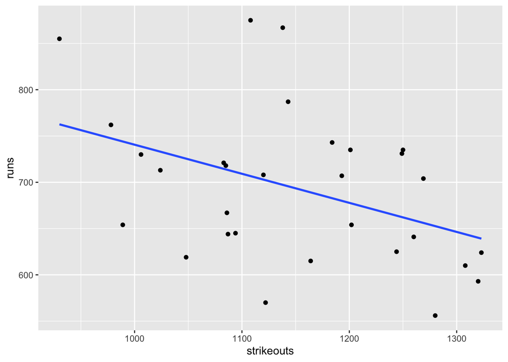

```r
# visual summaries
ex12_graph <- ggplot(mlb, aes(x=strikeouts, y=runs)) + geom_point() + stat_smooth(method="lm", se=FALSE)
print(ex12_graph)
```

This model seems to show a negative linear relationship between strikeouts and runs that is somewhat weak. There may be outliers under 600 runs.

## Question 3: Type 1 and Type 2 errors

Yes, it is possible for either J or T to make a type 1 error. For J and T, this would mean rejecting the null hypothesis that the proportion of adults in their neighborhood who have graduated from high school is equal to 0.94 when that proportion is indeed true.

Both are equally likely to make a type 1 error since this error only depends on the value of $alpha and the sample size doesn’t really matter in this case.

### Part a(ii)

No, it isn’t possible for either J or T to make a type 2 error. This means that J and T reject the alternative hypothesis that the proportion of adults in their neighborhood who’ve graduated from high school does not equal to 0.94, when the proportion truly isn’t equal to 0.94. However, we know that the proportion truly is equal to 0.94.

J is more likely to make a type 2 error since his sample size of 200 is a lot smaller than T’s sample size of 500. This is because the error rate decreases as the sample size increases. It wouldn’t really matter in this case though.

### Part b(i)

It is not possible for either J or T to make a Type 1 error since we know that the null hypothesis that the newspaper’s proportion of adults in their neighborhood who took chemistry of 0.25 is incorrect in the first place so even if we reject the null hypothesis, it isn’t true to begin with to make that error.

Type 1 error is also dependent in $alpha and not sample size so since they both have the same alpha value, they have equal likelihood of commiting an error if it was possible. It isn’t in this case.

### Part b(ii)

Yes, it is possible for either J or T to make a type 2 error. This means that J and T reject the alternative hypothesis that the proportion of adults in their neighborhood who’ve taken high school chemostry from high school does not equal to 0.25, when the proportion truly isn’t equal to 0.94.

J is more likely to make a type 2 error since his sample size of 200 is a lot smaller than T’s sample size of 500. This is because the error rate decreases as the sample size increases.